# EDA of Claims

Ryan Hawkins

December 5, 2018

## Important steps prior to exploration

If this is your first time running this code, Create a folder call Data in the project folder and place RDS files in there then source Import2.R FIRST to format your RDS files correctly does take a while to run, this is normal source(“Import2.R”). This is a vital step to ensure columns names and column types are the same.

```r
library(tidyverse)
library(scales)
```

## Data Import

Read in the data

```r
claimsFull <- readRDS("Data/claimsCleanFull.RDS")
```

## Factor Levels

Check out the levels of all factor variables

```r
claimsFull %>%
  select_if(is.factor) %>%
  map(nlevels) %>%
  unlist()
```

```
##             MRN_ALIAS            MEMBER_SEX             CLAIM_NUM
##                356797                     2              15058698
##           CURR_STATUS         REFERRAL_TYPE              MED_PRAC
##                    31                   148                  1627
##                CODE_1                CODE_2                CODE_3
##                 35061                 32398                 27075
##                CODE_4                CODE_5                CODE_6
##                 22724                 17307                 14512
##                CODE_7                CODE_8                CODE_9
##                 12796                 10604                  8963
##               CODE_10               CODE_11               CODE_12
##                  7893                  6902                  6063
##               CODE_13               CODE_14               CODE_15
##                  4832                  4320                  4037
##               CODE_16               CODE_17               CODE_18
##                  3646                  3237                  3026
##      PLACE_OF_SERVICE PLACE_OF_SERVICE_DESC          TYPE_OF_BILL
##                    50                    45                    76
##          TOB_CATEGORY          SERVICE_TYPE            CLAIM_TYPE
##                     5                     3                     2
##  ED_DISCHARGE_DX_DESC                  YEAR
##                 33611                     6
```

## Analysis First Steps

```r
# Select the most important columns
claims <- claimsFull %>%
  select(MRN_ALIAS, MEMBER_SEX,MEMBER_AGE,CLAIM_SEQ,EPISODE_SEQ,APPROVED_AMT,
         APPROVED_DAYS,ED_DISCHARGE_DX_DESC,PREVENTABILITY,ED_NOT_NEEDED_PROP,
         UNCLASSIFIED_ED, PCP_ID, VENDOR_PROV_ID, SERVICE_TYPE,CLAIM_TYPE,
         PLACE_OF_SERVICE_DESC, TOB_CATEGORY,YEAR) %>%
  arrange(MRN_ALIAS, CLAIM_SEQ, EPISODE_SEQ)

# Get rid of full data set to save on memory.
rm(claimsFull)

# Glimspe at the structure of claims
glimpse(claims)
```

```
## Observations: 15,061,887
## Variables: 18
## $ MRN_ALIAS             <fct> 0000073C4555, 0000073C4555, 0000073C4555...
## $ MEMBER_SEX            <fct> M, M, M, M, M, M, M, M, M, M, M, M, M, M...
## $ MEMBER_AGE            <dbl> 3, 3, 3, 3, 3, 3, 3, 5, 5, 5, 5, 5, 5, 5...
## $ CLAIM_SEQ             <dbl> 1, 2, 3, 4, 5, 6, 7, 8, 9, 10, 11, 12, 1...
## $ EPISODE_SEQ           <dbl> 1, 2, 3, 4, 4, 5, 6, 7, 8, 8, 9, 9, 10, ...
## $ APPROVED_AMT          <dbl> 302.00, 160.02, 42.76, 2964.56, 160.50, ...
## $ APPROVED_DAYS         <dbl> 0, 0, 0, 0, 0, 0, 0, 0, 0, 0, 0, 0, 0, 0...
## $ ED_DISCHARGE_DX_DESC  <fct> Other developmental speech or language d...
## $ PREVENTABILITY        <dbl> 0.00000000, 0.00000000, 0.00000000, 0.00...
## $ ED_NOT_NEEDED_PROP    <dbl> 0.00000000, 0.00000000, 0.00000000, 0.00...
## $ UNCLASSIFIED_ED       <dbl> 0.00000000, 1.00000000, 1.00000000, 1.00...
## $ PCP_ID                <dbl> 92289, 92289, 92289, 92289, 92289, 92289...
## $ VENDOR_PROV_ID        <dbl> 12429, 12429, 69832, 12429, 82061, 12429...
## $ SERVICE_TYPE          <fct> OTPT, OTPT, OTPT, OTPT, OTPT, OTPT, OTPT...
## $ CLAIM_TYPE            <fct> FACILITY, FACILITY, PROFESSIONAL, FACILI...
## $ PLACE_OF_SERVICE_DESC <fct> NA, NA, OFFICE, NA, ON CAMPUS - OUTPATIE...
## $ TOB_CATEGORY          <fct> OUTPATIENT SERVICES, OUTPATIENT SERVICES...
## $ YEAR                  <fct> 2014, 2014, 2014, 2014, 2014, 2014, 2014...
```

```r
# View summary of columns, takes some time to run
summary(claims)
```

```
##         MRN_ALIAS        MEMBER_SEX    MEMBER_AGE      CLAIM_SEQ
##  D22788B075E4:    2953   F:9361133   Min.   : 0.00   Min.   :    1.00
##  01057C38C16B:    2642   M:5700754   1st Qu.: 7.00   1st Qu.:   15.00
##  6340FD1E9F88:    2459               Median :18.00   Median :   40.00
##  19BFAC8C1046:    2396               Mean   :23.71   Mean   :   97.89
##  494B7F5A7E9C:    2271               3rd Qu.:39.00   3rd Qu.:  103.00
##  D8E5447335DE:    2268               Max.   :89.00   Max.   :29886.00
##  (Other)     :15046898               NA's   :1346
##   EPISODE_SEQ       APPROVED_AMT       APPROVED_DAYS
##  Min.   :   1.00   Min.   :      0.0   Min.   :  0.000
##  1st Qu.:  10.00   1st Qu.:     41.2   1st Qu.:  0.000
##  Median :  25.00   Median :     73.2   Median :  0.000
##  Mean   :  56.68   Mean   :    195.0   Mean   :  0.088
##  3rd Qu.:  60.00   3rd Qu.:    118.8   3rd Qu.:  0.000
##  Max.   :1972.00   Max.   :1977966.9   Max.   :536.000
##
##                                                                ED_DISCHARGE_DX_DESC
##  Other general symptoms and signs                                        :  667307
##  Routine infant or child health check                                    :  405615
##  Other general symptoms                                                  :  361639
##  Encounter for routine child health examination without abnormal findings:  276625
##  Assault by transport vehicle                                            :  187122
##  Attention deficit disorder with hyperactivity                           :  146915
##  (Other)                                                                 :13016664
##  PREVENTABILITY  ED_NOT_NEEDED_PROP UNCLASSIFIED_ED     PCP_ID
##  Min.   :0.00    Min.   :0.00       Min.   :0.00    Min.   :    143
##  1st Qu.:0.00    1st Qu.:0.00       1st Qu.:0.00    1st Qu.:  28836
##  Median :0.00    Median :0.00       Median :0.00    Median :  76754
##  Mean   :0.04    Mean   :0.36       Mean   :0.36    Mean   : 176446
##  3rd Qu.:0.00    3rd Qu.:0.88       3rd Qu.:1.00    3rd Qu.:  91981
##  Max.   :1.00    Max.   :1.00       Max.   :1.00    Max.   :8000908
##  NA's   :70121   NA's   :70121      NA's   :72293   NA's   :11162
##  VENDOR_PROV_ID      SERVICE_TYPE           CLAIM_TYPE
##  Min.   :       16   ED  :  970843   FACILITY    : 2200169
##  1st Qu.:    24956   INPT:  161420   PROFESSIONAL:12861718
##  Median :    57892   OTPT:13929624
##  Mean   :   189891
##  3rd Qu.:    87590
##  Max.   :541217184
##
##                     PLACE_OF_SERVICE_DESC
##  OFFICE                        :7075048
##  EMERGENCY ROOM - HOSPITAL     :1493180
##  ON CAMPUS - OUTPATIENT HOSPITA: 915410
##  INPATIENT HOSPITAL            : 860473
##  INDEPENDENT LABORATORY        : 722626
##  (Other)                       :1787931
##  NA's                          :2207219
##                      TOB_CATEGORY        YEAR
##  HOME HEALTH               :   56060   2013:2303803
##  HOSPITAL INPATIENT        :  161310   2014:2323650
##  OUTPATIENT SERVICES       : 1980575   2015:2563332
##  SKILLED NURSING INPATIENT :      81   2016:2723925
##  SKILLED NURSING OUTPATIENT:      13   2017:2807906
##  NA's                      :12863848   2018:2339271
##
```

### Relationship Between Variables

I want to get a good understanding of the factor variable and the relationships between one another. For instance FACILITY is the place, PROFESSIONAL is the person who saw you. ED will always be a FACILITY claim. Furthermore, if it’s in a facility, it will have TOB- hospital, outpatient surgery center (like a place that only does appendix removals without overnight check ins). You still have to have a professional claim associated with that visit. ED always has a facility claim. Urgent care is an outpatient professional. Does the data reflect this

```r
# Number of Patient Types(Inpatient, Outpatient or ED) by Claim Type(Facility or Professional)
claims %>% select(SERVICE_TYPE, CLAIM_TYPE) %>%
  table()
```

```
##             CLAIM_TYPE
## SERVICE_TYPE FACILITY PROFESSIONAL
##         ED     970788           55
##         INPT   161420            0
##         OTPT  1067961     12861663
```

```r
# Type of Bill Category by Patient Type
claims %>% select(TOB_CATEGORY,SERVICE_TYPE) %>%
  table()
```

```
##                             SERVICE_TYPE
## TOB_CATEGORY                      ED    INPT    OTPT
##   HOME HEALTH                      7       0   56053
##   HOSPITAL INPATIENT               0  161309       1
##   OUTPATIENT SERVICES         970304       0 1010271
##   SKILLED NURSING INPATIENT        0       0      81
##   SKILLED NURSING OUTPATIENT       2       0      11
```

### Looking at Membership

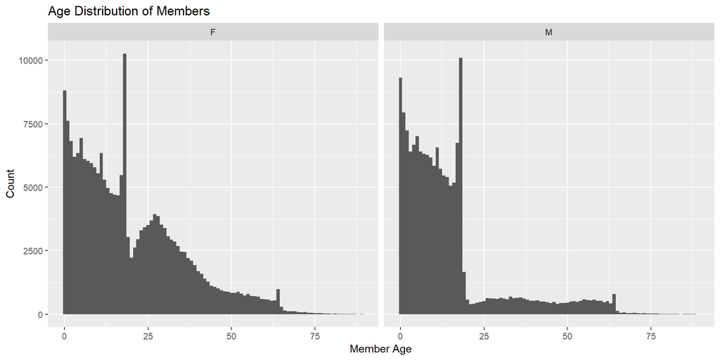

```r
# Distribution of Member age
claims %>%
  group_by(MRN_ALIAS, MEMBER_SEX) %>%
  summarize(Age = max(MEMBER_AGE)) %>%
  ggplot(aes(Age))+
  geom_histogram(bins = 90)+
  facet_wrap(~MEMBER_SEX)+
  labs(x = "Member Age",y="Count", title="Age Distribution of Members")
```

The two columns of most importance are PREVENTABILITY and ED_NOT_NEEDED. They share some commonality but for the purpose of this analysis should be consider separately. ED visits for a diagnosis with PREVENTABILITY of 1 indicates ED visit is required but could have been prevented entirely through routine check ups with a PCP. ED visits for a diagnosis with a ED_NOT_NEEDED of 1 indicates the condition was not life threatening and treatable at an Urgent Care facility.

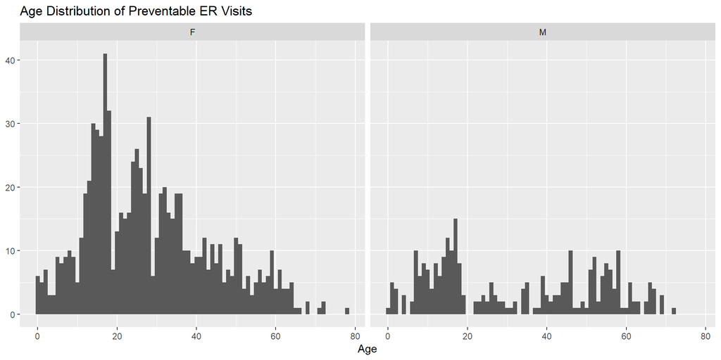

```r
# Age distrbution of Preventable ED
claims %>%
  select(SERVICE_TYPE, PREVENTABILITY, MEMBER_AGE, MEMBER_SEX) %>%
  filter(SERVICE_TYPE == 'ED' & (PREVENTABILITY == 1)) %>%
  ggplot(aes(MEMBER_AGE)) +
  geom_histogram(binwidth = 1)+
  facet_wrap(~MEMBER_SEX)+
  labs(title='Age Distribution of Preventable ER Visits', x = 'Age', y = NULL)
```

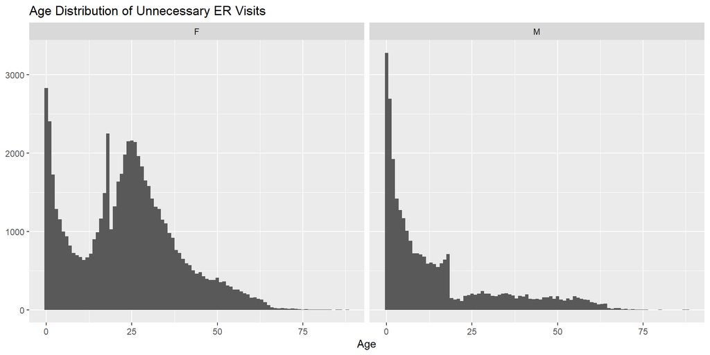

```r
# Age distrbution of ED_NOT_NEEDED visits
claims %>%
  select(SERVICE_TYPE,  ED_NOT_NEEDED_PROP, MEMBER_AGE, MEMBER_SEX) %>%
  filter(SERVICE_TYPE == 'ED' & (ED_NOT_NEEDED_PROP == 1)) %>%
  ggplot(aes(MEMBER_AGE)) +
  geom_histogram(binwidth = 1)+
  facet_wrap(~MEMBER_SEX)+
  labs(title='Age Distribution of Unnecessary ER Visits', x = 'Age', y = NULL)
```

How often do members see their listed primary care physician(PCP). Members who get routine check ups by someone other than their listed PCP will not be counted.

```r
# How many times have members seen there PCP
claims %>%
  filter(PCP_ID == VENDOR_PROV_ID) %>%
  count(MRN_ALIAS, sort = TRUE) %>%
  head()
```

| MRN_ALIAS | n |
| --- | --- |
| ABB8207E5498 | 108 |
| B4CB12C440DE | 96 |
| A7C7CCF02330 | 90 |
| AB4E56FF10F3 | 87 |
| 6E6C5D15A5DC | 76 |
| AA429E1C0CA2 | 67 |

```r
# How many members is that
claims %>%
  filter(PCP_ID == VENDOR_PROV_ID) %>%
  count(MRN_ALIAS, sort = TRUE) %>%
  nrow()
```

```
## [1] 8009
```

How many members have more than 100 claims? The median claims is 40.

```r
# Number of memebers with more than 100 claims
claims %>%
  group_by(MRN_ALIAS) %>%
  summarize(max_claim_seq = max(CLAIM_SEQ)) %>%
  ungroup %>%
  filter(max_claim_seq > 100) %>%
  nrow()
```

```
## [1] 37535
```

### Distribution of Diagnosis scores

In addition to the explanation above. A diagnosis can all have a UNCLASSIFIED_ED score with 1 indicating there is no PREVENTABLITY or ED_NOT_NEEDED score associated to that diagnosis. This can also be a proportion.

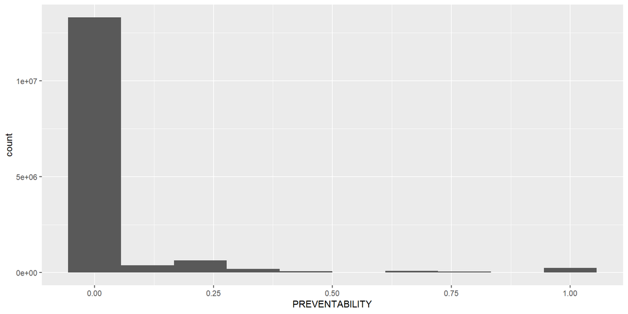

```r
# Distribution of PREVENTIBLITY score
claims %>%
  ggplot(aes(PREVENTABILITY))+
  geom_histogram(bins = 10)
```

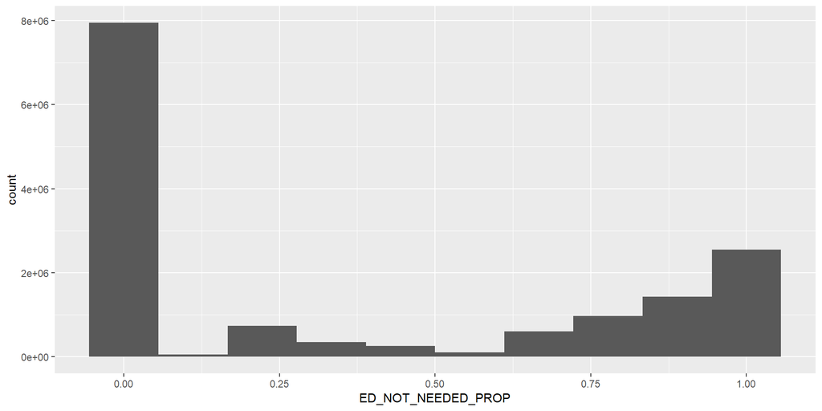

```r
# Distribution of ED_NOT_NEEDED score
claims %>%
  ggplot(aes(ED_NOT_NEEDED_PROP))+
  geom_histogram(bins = 10)
```

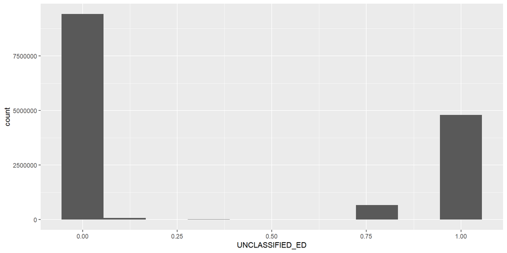

```r
# Distributino of UNCLASSIFIED_ED
claims %>%
  ggplot(aes(UNCLASSIFIED_ED))+
  geom_histogram(bins = 10)
```

### Past Visits to the ER

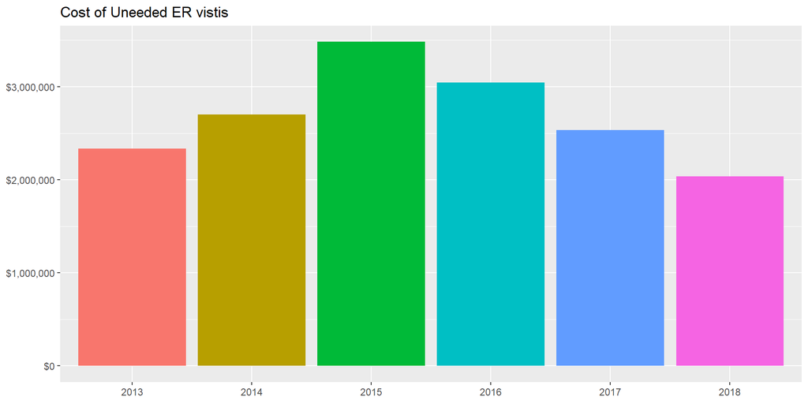

```r
# Total amount of money spent on ER claims that were 100% preventable or 100% not er needed
claims %>%
  select(ED_DISCHARGE_DX_DESC,SERVICE_TYPE, PREVENTABILITY, ED_NOT_NEEDED_PROP, APPROVED_AMT, YEAR) %>%
  filter(SERVICE_TYPE == 'ED' & (ED_NOT_NEEDED_PROP == 1 | PREVENTABILITY == 1)) %>%
  group_by(YEAR) %>%
  summarize(Total_Cost = sum(APPROVED_AMT)) %>%
  ggplot(aes(YEAR, Total_Cost, fill = YEAR))+
  geom_col()+
  scale_y_continuous(labels = dollar_format())+
  labs(title = 'Cost of Uneeded ER vistis', x = NULL, y = NULL)+
  theme(legend.position="none")
```

What preventable diagnoses are most members going to the ED for?

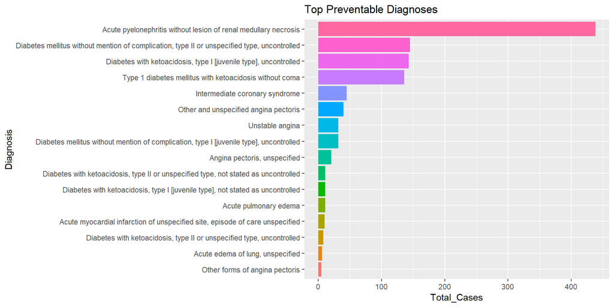

```r
# Most comman preventably ER diagnosis
claims %>%
  select(ED_DISCHARGE_DX_DESC,SERVICE_TYPE, PREVENTABILITY,APPROVED_AMT, YEAR) %>%
  filter(SERVICE_TYPE == 'ED' & (PREVENTABILITY == 1)) %>%
  group_by(ED_DISCHARGE_DX_DESC) %>%
  summarize(Total_Cases = n()) %>%
  arrange(desc(Total_Cases)) %>%
  head(n = 25) %>%
  ggplot(aes(fct_reorder(ED_DISCHARGE_DX_DESC,Total_Cases),
             Total_Cases,fill = fct_reorder(ED_DISCHARGE_DX_DESC,Total_Cases)))+
  geom_col()+
  coord_flip()+
  labs(x = 'Diagnosis', title = 'Top Preventable Diagnoses')+
  theme(legend.position="none")
```

What ed not needed diagnoses are most members going to the ED for?

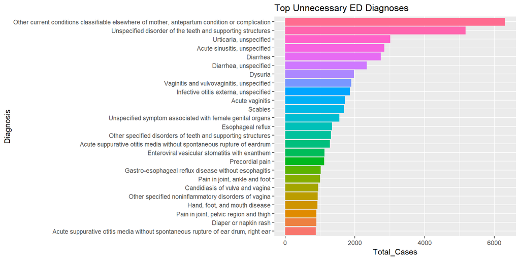

```r
# Most comman unnecessary ER diagnosis
claims %>%
  select(ED_DISCHARGE_DX_DESC,SERVICE_TYPE, ED_NOT_NEEDED_PROP,APPROVED_AMT, YEAR) %>%
  filter(SERVICE_TYPE == 'ED' & (ED_NOT_NEEDED_PROP == 1)) %>%
  group_by(ED_DISCHARGE_DX_DESC) %>%
  summarize(Total_Cases = n()) %>%
  arrange(desc(Total_Cases)) %>%
  head(n = 25) %>%
  ggplot(aes(fct_reorder(ED_DISCHARGE_DX_DESC,Total_Cases),
             Total_Cases,fill = fct_reorder(ED_DISCHARGE_DX_DESC,Total_Cases)))+
  geom_col()+
  coord_flip()+
  labs(x = 'Diagnosis', title = 'Top Unnecessary ED Diagnoses')+
  theme(legend.position="none")
```

Who are the habitual visitors of the ER when wether its completely preventable or unnecessary?

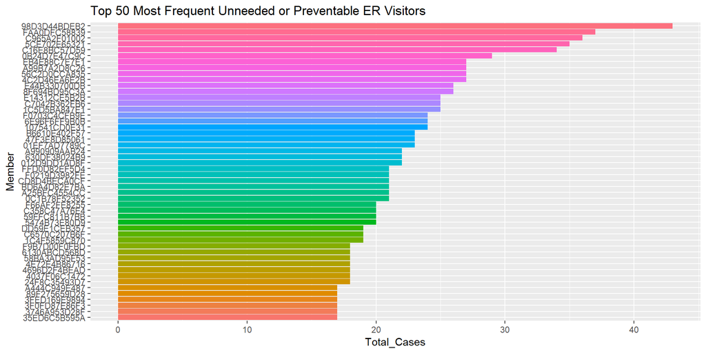

```r
# Most Unneeded or Preventable ER visitors
claims %>%
  select(ED_DISCHARGE_DX_DESC,SERVICE_TYPE, PREVENTABILITY, ED_NOT_NEEDED_PROP, APPROVED_AMT, YEAR, MRN_ALIAS) %>%
  filter(SERVICE_TYPE == 'ED' & (ED_NOT_NEEDED_PROP == 1 | PREVENTABILITY == 1)) %>%
  group_by(MRN_ALIAS) %>%
  summarize(Total_Cases = n()) %>%
  arrange(desc(Total_Cases)) %>%
  head(n = 50) %>%
  ggplot(aes(fct_reorder(MRN_ALIAS,Total_Cases), Total_Cases,fill = fct_reorder(MRN_ALIAS,Total_Cases)))+
  geom_col()+
  coord_flip()+
  labs(x = 'Member', title = 'Top 50 Most Frequent Unneeded or Preventable ER Visitors')+
  theme(legend.position="none")
```

Which members are costing the most money?

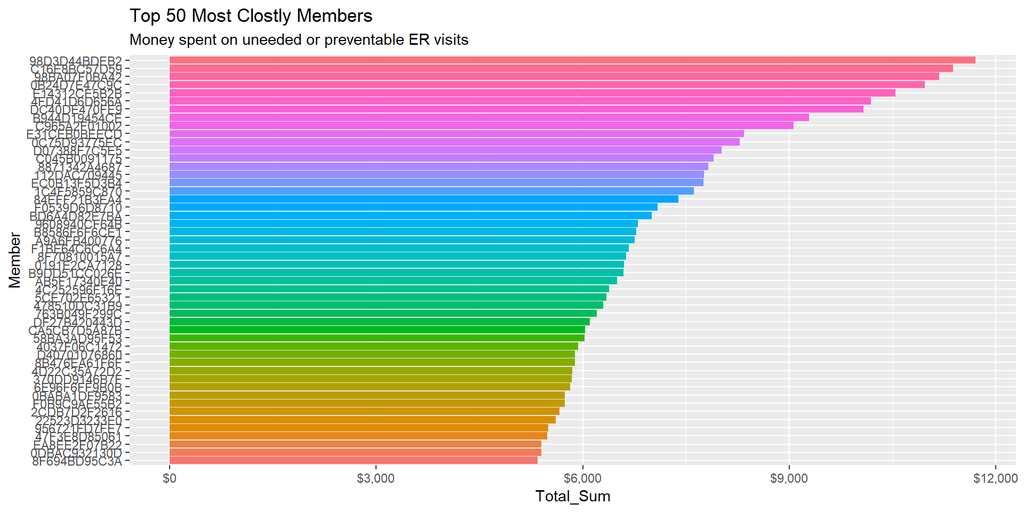

```r
# Most Costly ER visitors that are preventable or unnecessary
claims %>%
  select(ED_DISCHARGE_DX_DESC,SERVICE_TYPE, PREVENTABILITY, ED_NOT_NEEDED_PROP, APPROVED_AMT, YEAR, MRN_ALIAS) %>%
  filter(SERVICE_TYPE == 'ED' & (ED_NOT_NEEDED_PROP == 1 | PREVENTABILITY == 1)) %>%
  group_by(MRN_ALIAS) %>%
  summarize(Total_Sum = sum(APPROVED_AMT)) %>%
  arrange(desc(Total_Sum)) %>%
  head(n = 50) %>%
  ggplot(aes(fct_reorder(MRN_ALIAS,Total_Sum), Total_Sum,fill = fct_reorder(MRN_ALIAS,Total_Sum)))+
  geom_col()+
  coord_flip()+
  labs(x = 'Member', title = 'Top 50 Most Clostly Members', subtitle = 'Money spent on uneeded or preventable ER visits')+
  scale_y_continuous(labels = dollar_format())+
  theme(legend.position="none")
```

Lets take a closer look at the #1 ED Lover (or ED hater depending on how you look at it).

```r
# 98D3D44BDEB2 has the most unneeded or prevnetable visits and the most costly
claims %>%
  filter(MRN_ALIAS == '98D3D44BDEB2',SERVICE_TYPE == 'ED' &
        (ED_NOT_NEEDED_PROP == 1 | PREVENTABILITY == 1)) %>%
  arrange(MRN_ALIAS, CLAIM_SEQ, EPISODE_SEQ) %>%
  select(MEMBER_AGE, MEMBER_SEX,CLAIM_SEQ,EPISODE_SEQ,ED_DISCHARGE_DX_DESC,PREVENTABILITY,
         ED_NOT_NEEDED_PROP, UNCLASSIFIED_ED, SERVICE_TYPE)
```

| MEMBER_AGE | MEMBER_SEX | CLAIM_SEQ | EPISODE_SEQ | ED_DISCHARGE_DX_DESC | PREVENTABILITY | ED_NOT_NEEDED_PROP | UNCLASSIFIED_ED | SERVICE_TYPE |
| --- | --- | --- | --- | --- | --- | --- | --- | --- |
| 65 | M | 93 | 31 | Pain in joint, pelvic region and thigh | 0 | 1 | 0 | ED |
| 65 | M | 110 | 41 | Diarrhea | 0 | 1 | 0 | ED |
| 65 | M | 126 | 51 | Pain in joint, pelvic region and thigh | 0 | 1 | 0 | ED |
| 65 | M | 137 | 55 | Pain in joint, pelvic region and thigh | 0 | 1 | 0 | ED |
| 65 | M | 138 | 56 | Pain in joint, pelvic region and thigh | 0 | 1 | 0 | ED |
| 65 | M | 158 | 61 | Other and unspecified angina pectoris | 1 | 0 | 0 | ED |
| 65 | M | 215 | 81 | Coronary atherosclerosis of unspecified type of vessel, native or graft | 0 | 1 | 0 | ED |
| 65 | M | 267 | 99 | Other and unspecified angina pectoris | 1 | 0 | 0 | ED |
| 66 | M | 312 | 112 | Coronary atherosclerosis of native coronary artery | 0 | 1 | 0 | ED |
| 66 | M | 325 | 114 | Other and unspecified angina pectoris | 1 | 0 | 0 | ED |
| 66 | M | 399 | 133 | Precordial pain | 0 | 1 | 0 | ED |
| 66 | M | 415 | 139 | Other and unspecified angina pectoris | 1 | 0 | 0 | ED |
| 66 | M | 448 | 147 | Precordial pain | 0 | 1 | 0 | ED |
| 66 | M | 542 | 177 | Precordial pain | 0 | 1 | 0 | ED |
| 66 | M | 567 | 183 | Other and unspecified angina pectoris | 1 | 0 | 0 | ED |
| 66 | M | 568 | 184 | Other and unspecified angina pectoris | 1 | 0 | 0 | ED |
| 66 | M | 578 | 186 | Intermediate coronary syndrome | 1 | 0 | 0 | ED |
| 67 | M | 608 | 197 | Other and unspecified angina pectoris | 1 | 0 | 0 | ED |
| 67 | M | 618 | 199 | Precordial pain | 0 | 1 | 0 | ED |
| 67 | M | 642 | 210 | Arthropathy, unspecified, pelvic region and thigh | 0 | 1 | 0 | ED |
| 67 | M | 644 | 211 | Other and unspecified angina pectoris | 1 | 0 | 0 | ED |
| 67 | M | 647 | 213 | Pain in joint, pelvic region and thigh | 0 | 1 | 0 | ED |
| 67 | M | 673 | 221 | Pain in joint, pelvic region and thigh | 0 | 1 | 0 | ED |
| 67 | M | 692 | 229 | Arthropathy, unspecified, pelvic region and thigh | 0 | 1 | 0 | ED |
| 67 | M | 704 | 234 | Pain in joint, pelvic region and thigh | 0 | 1 | 0 | ED |
| 67 | M | 709 | 236 | Pain in joint, pelvic region and thigh | 0 | 1 | 0 | ED |
| 67 | M | 720 | 241 | Pain in joint, pelvic region and thigh | 0 | 1 | 0 | ED |
| 67 | M | 737 | 246 | Intermediate coronary syndrome | 1 | 0 | 0 | ED |
| 67 | M | 761 | 252 | Other and unspecified angina pectoris | 1 | 0 | 0 | ED |
| 67 | M | 774 | 258 | Pain in joint, pelvic region and thigh | 0 | 1 | 0 | ED |
| 67 | M | 777 | 260 | Pain in joint, pelvic region and thigh | 0 | 1 | 0 | ED |
| 67 | M | 811 | 271 | Other follow-up examination | 0 | 1 | 0 | ED |
| 68 | M | 822 | 276 | Other follow-up examination | 0 | 1 | 0 | ED |
| 68 | M | 827 | 279 | Coronary atherosclerosis of unspecified type of vessel, native or graft | 0 | 1 | 0 | ED |
| 68 | M | 863 | 289 | Trochanteric bursitis, left hip | 0 | 1 | 0 | ED |
| 68 | M | 872 | 292 | Pain in left hip | 0 | 1 | 0 | ED |
| 68 | M | 1068 | 358 | Pain in left hip | 0 | 1 | 0 | ED |
| 69 | M | 1175 | 393 | Disorder of the skin and subcutaneous tissue, unspecified | 0 | 1 | 0 | ED |
| 69 | M | 1182 | 397 | Unstable angina | 1 | 0 | 0 | ED |
| 69 | M | 1222 | 410 | Pain in unspecified hip | 0 | 1 | 0 | ED |
| 69 | M | 1233 | 413 | Unstable angina | 1 | 0 | 0 | ED |
| 69 | M | 1266 | 427 | Unstable angina | 1 | 0 | 0 | ED |
| 69 | M | 1277 | 430 | Pain in left hip | 0 | 1 | 0 | ED |